# Cyclistic Bike-Share: Case Study

Devin

2023-12-03

# **Business Objective:**

We want to figure out how members who use Cyclistic Bikes differ from those who use them casually. The goal is to understand in simple terms how these two groups use the bikes in different ways. This understanding will help us make smarter decisions for the business and come up with ideas to convert casual riders to members.

# Processing Data

As the data was provided in monthly csv. files, I wanted to combined all of the months into one table to show a years’ worth of data. I checked each csv file to ensure the data types would match and combined into one table. Then I removed columns that were of no use for the business objective and created new columns for analysis.

```r
# Install necessary packages for analysis
chooseCRANmirror(graphics=FALSE, ind=1)
knitr::opts_chunk$set(echo = TRUE)

library(tidyverse)
library(lubridate)
library(ggplot2)
library(gridExtra)
library(knitr)

# Changing directory to pull csv files into R
getwd()
setwd("C:/Users/Devin Quach/Documents/Data Analytics/Cyclistic Bikes Data/.csv/2022")
jan_2022 <- read_csv("2022_01-divvy-tripdata.csv")
feb_2022 <- read_csv("2022_02-divvy-tripdata.csv")
mar_2022 <- read_csv("2022_03-divvy-tripdata.csv")
apr_2022 <- read_csv("2022_04-divvy-tripdata.csv")
may_2022 <- read_csv("2022_05-divvy-tripdata.csv")
jun_2022 <- read_csv("2022_06-divvy-tripdata.csv")
jul_2022 <- read_csv("2022_07-divvy-tripdata.csv")
aug_2022 <- read_csv("2022_08-divvy-tripdata.csv")
sep_2022 <- read_csv("2022_09-divvy-publictripdata.csv")
oct_2022 <- read_csv("2022_10-divvy-tripdata.csv")
nov_2022 <- read_csv("2022_11-divvy-tripdata.csv")
dec_2022 <- read_csv("2022_12-divvy-tripdata.csv")

# Viewing and changing col names to ensure they match to combine
colnames(jan_2022)
colnames(dec_2022)

# viewing structure of tables to ensure same data types are used
str(jan_2022)
str(feb_2022)
str(dec_2022)

# Combine data into one big year table
year_2022 <- bind_rows(jan_2022,feb_2022,mar_2022,apr_2022,may_2022,jun_2022,jul_2022,aug_2022,sep_2022,oct_2022,nov_2022,dec_2022)

# Remove unused columns
year_2022 <- year_2022 %>%
  select(-c(start_lat,start_lng,end_lat,end_lng))

# Add columns for date,month, day, year, ride_duration, and day_of_week
year_2022 <- year_2022 %>% add_column(date = as.Date(year_2022$started_at),.after = "ended_at")
year_2022 <- year_2022 %>% add_column(year = format(year_2022$date, "%Y"), .after = "date")
year_2022 <- year_2022 %>% add_column(day = format(year_2022$date, "%d"), .after = "date")
year_2022 <- year_2022 %>% add_column(month = format(year_2022$date, "%m"), .after = "date")
year_2022 <- year_2022 %>% add_column(duration = difftime(year_2022$ended_at,year_2022$started_at), .after = "ended_at")
year_2022 <- year_2022 %>% add_column(day_of_week = wday(year_2022$date), .after="year")
year_2022 <- year_2022 %>% add_column(hour = format(as.POSIXct(year_2022$started_at), format = "%H"), .after = "year")


# Removes ride that started from HQ QR & rides that have negative duration
year_2022v2 <- year_2022[!(year_2022$start_station_name == "HQ QR" | year_2022$duration <= 0),]

# Removes rides that have no duration data
year_2022v2 <- year_2022v2[complete.cases(year_2022v2[, c('duration')]),]
```

# Final Dataset Used

The finalized clean dataset I used for the analysis is the “year_2022v2” dataset shown below.

```r
kable(head(year_2022v2))
```

| ride_id | rideable_type | started_at | ended_at | duration | date | month | day | year | hour | day_of_week | start_station_name | start_station_id | end_station_name | end_station_id | member_casual |
| --- | --- | --- | --- | --- | --- | --- | --- | --- | --- | --- | --- | --- | --- | --- | --- |
| C2F7DD78E82EC875 | electric_bike | 2022-01-13 11:59:47 | 2022-01-13 12:02:44 | 177 secs | 2022-01-13 | 01 | 13 | 2022 | 11 | 5 | Glenwood Ave & Touhy Ave | 525 | Clark St & Touhy Ave | RP-007 | casual |
| A6CF8980A652D272 | electric_bike | 2022-01-10 08:41:56 | 2022-01-10 08:46:17 | 261 secs | 2022-01-10 | 01 | 10 | 2022 | 08 | 2 | Glenwood Ave & Touhy Ave | 525 | Clark St & Touhy Ave | RP-007 | casual |
| BD0F91DFF741C66D | classic_bike | 2022-01-25 04:53:40 | 2022-01-25 04:58:01 | 261 secs | 2022-01-25 | 01 | 25 | 2022 | 04 | 3 | Sheffield Ave & Fullerton Ave | TA1306000016 | Greenview Ave & Fullerton Ave | TA1307000001 | member |
| CBB80ED419105406 | classic_bike | 2022-01-04 00:18:04 | 2022-01-04 00:33:00 | 896 secs | 2022-01-04 | 01 | 04 | 2022 | 00 | 3 | Clark St & Bryn Mawr Ave | KA1504000151 | Paulina St & Montrose Ave | TA1309000021 | casual |
| DDC963BFDDA51EEA | classic_bike | 2022-01-20 01:31:10 | 2022-01-20 01:37:12 | 362 secs | 2022-01-20 | 01 | 20 | 2022 | 01 | 5 | Michigan Ave & Jackson Blvd | TA1309000002 | State St & Randolph St | TA1305000029 | member |
| A39C6F6CC0586C0B | classic_bike | 2022-01-11 18:48:09 | 2022-01-11 18:51:31 | 202 secs | 2022-01-11 | 01 | 11 | 2022 | 18 | 3 | Wood St & Chicago Ave | 637 | Honore St & Division St | TA1305000034 | member |

# Data Analysis

### Statistical Analysis

To gain a better understanding of the ride_durations I found the statistical mean, median, and max.

```r
aggregate(year_2022v2$duration ~ year_2022v2$member_casual, FUN=mean)
```

```
##   year_2022v2$member_casual year_2022v2$duration
## 1                    casual       1901.3002 secs
## 2                    member        770.3431 secs
```

```r
aggregate(year_2022v2$duration ~ year_2022v2$member_casual, FUN=median)
```

```
##   year_2022v2$member_casual year_2022v2$duration
## 1                    casual             814 secs
## 2                    member             536 secs
```

```r
aggregate(year_2022v2$duration ~ year_2022v2$member_casual, FUN=max)
```

```
##   year_2022v2$member_casual year_2022v2$duration
## 1                    casual         2483235 secs
## 2                    member           93594 secs
```

```r
aggregate(year_2022v2$duration ~ year_2022v2$member_casual + year_2022v2$day_of_week, FUN = mean)
```

```
##    year_2022v2$member_casual year_2022v2$day_of_week year_2022v2$duration
## 1                     casual                       1       2216.2441 secs
## 2                     member                       1        854.9136 secs
## 3                     casual                       2       1903.9112 secs
## 4                     member                       2        743.0700 secs
## 5                     casual                       3       1685.1483 secs
## 6                     member                       3        733.1621 secs
## 7                     casual                       4       1614.1603 secs
## 8                     member                       4        731.7482 secs
## 9                     casual                       5       1665.4006 secs
## 10                    member                       5        743.9445 secs
## 11                    casual                       6       1837.8636 secs
## 12                    member                       6        758.3670 secs
## 13                    casual                       7       2117.3352 secs
## 14                    member                       7        862.2540 secs
```

These metrics demonstrates that casual riders ride for much longer everyday compared to members.

### HOW MEMBERS DIFFER:

By plotting the number of rides and average duration of rides everyday per member type, we can see that casual riders have less but longer duration rides than members do. This maybe due to the fact that casual riders do not want to pay for extra rides instead they just use one very long ride. It also seems like members use the program a lot more on weekdays than casual riders do. For the weekends, it looks like casual riders and members are even in the number of rides.

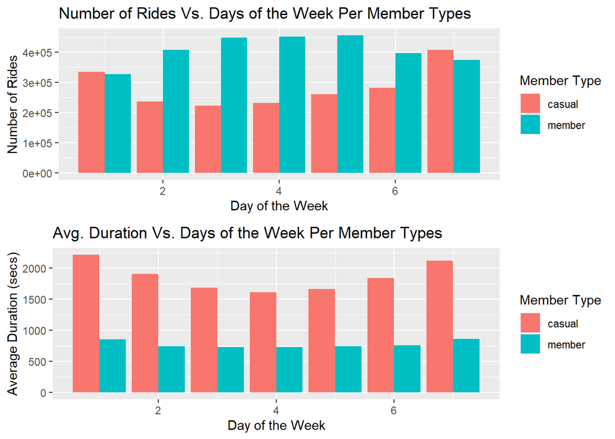

```r
# Let's visualize the number of rides by rider type
rides_v_days <- year_2022v2 %>%
  group_by(member_casual, day_of_week) %>%  #groups by user_type and day_of_week
  summarise(number_of_rides = n()                           #calculates the number of rides and average duration
            ,average_duration = mean(duration)) %>%         # calculates the average duration
  arrange(member_casual, day_of_week)   %>%
  ggplot(aes(x = day_of_week, y = number_of_rides, fill = member_casual)) +
  geom_col(position = "dodge") +
  labs(x = "Day of the Week", y = "Number of Rides", title = "Number of Rides Vs. Days of the Week Per Member Types", fill='Member Type')

# Let's visualize the duration of rides by rider type - Casuals rode for longer than members
duration_v_days <- year_2022v2 %>%
  group_by(member_casual, day_of_week) %>%  #groups by user_type and day_of_week
  summarise(number_of_rides = n()                           #calculates the number of rides and average duration
            ,average_duration = mean(duration)) %>%         # calculates the average duration
  arrange(member_casual, day_of_week)   %>%
  ggplot(aes(x = day_of_week, y = average_duration, fill = member_casual)) +
  geom_col(position = "dodge") +
  labs(x = "Day of the Week", y = "Average Duration (secs)", title = "Avg. Duration Vs. Days of the Week Per Member Types", fill='Member Type')

grid.arrange(rides_v_days, duration_v_days, nrow=2)
```

### WHAT MEMBERS DIFFER IN:

Plotting the type of rides by the number of rides per member type, shows that casual riders use all three type of rides whereas members only use electric and classic bikes. For casual riders, it looks like there is no preference between classic and electric bikes but docked bikes are barely used. For members, they seem to prefer classic bikes more than electric bikes.

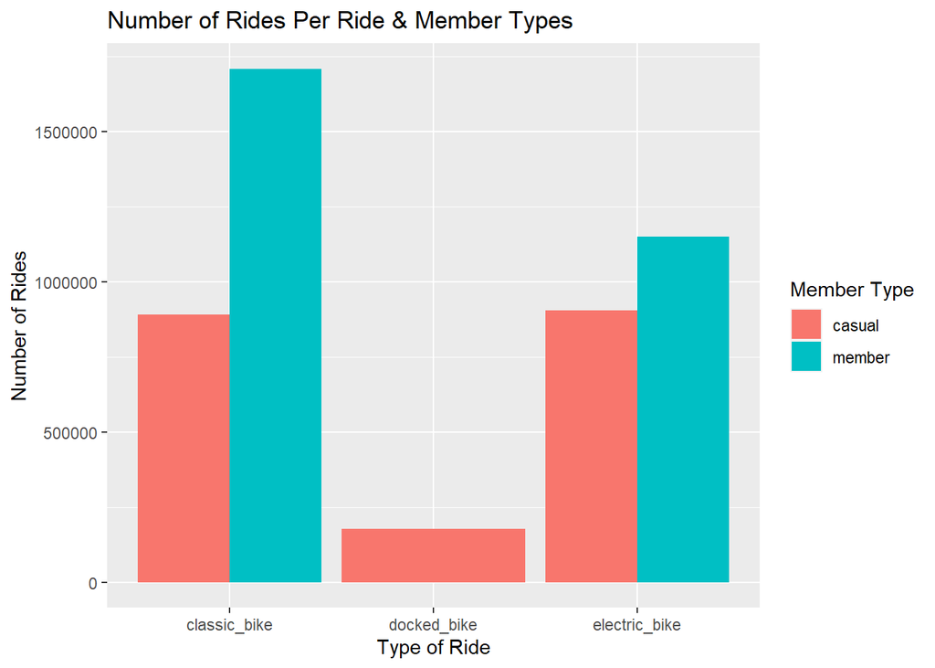

```r
# Visualize the number of rides by rider type by rideable_type
year_2022v2 %>%
  group_by(member_casual, rideable_type) %>%  #groups by user_type and ride_type
  summarise(number_of_rides = n()) %>%                  #calculates the number of rides
  arrange(member_casual, rideable_type) %>%
  ggplot(aes(x = rideable_type, y = number_of_rides, fill = member_casual)) +
  geom_col(position = "dodge") +
  labs(x = "Type of Ride", y = "Number of Rides", title = "Number of Rides Per Ride & Member Types", fill='Member Type')
```

### WHEN MEMBERS DIFFER:

Plotting when rides occur during an average day shows that casual riders use the program mostly in the evenings whereas members use it during the morning and evenings. I believe this shows that casual riders like to only use to program to leave work and members use it to go to and leave work.

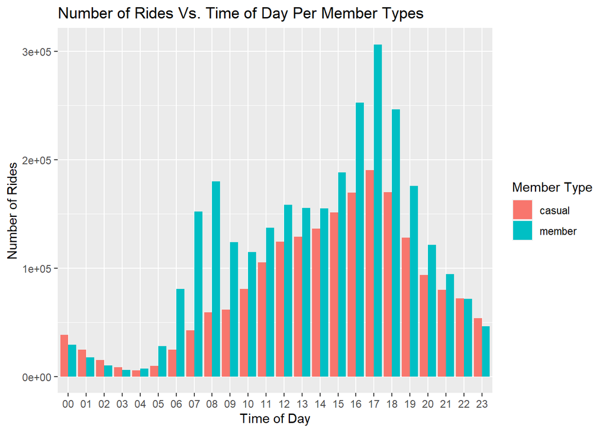

```r
year_2022v2 %>%
  group_by(member_casual, hour) %>%  #groups by user_type and time of day
  summarise(number_of_rides = n()) %>%                  #calculates the number of rides
  arrange(member_casual, hour)  %>%
  ggplot(aes(x = hour, y = number_of_rides, fill = member_casual)) +
  geom_col(position = "dodge") +
  labs(x = "Time of Day", y = "Number of Rides", title = "Number of Rides Vs. Time of Day Per Member Types", fill='Member Type')
```

# Conclusion

**Time-Based Charging Model:** Implementing a time-based charging structure, as opposed to a per-ride model, presents a potentially advantageous approach. Analyzing the 2022 data reveals instances where casual riders prolonged their rides for extensive durations, with the longest recorded ride spanning 28.7 days. Moreover, casual members averaged 19 minutes more per ride than their member counterparts. Transitioning to a pricing model based on 15-minute intervals could incentivize casual riders to opt for a membership, optimizing benefits while ensuring efficient bike utilization and reducing prolonged unavailability.

**Incentivizing Morning and Evening Rides:** Capitalizing on the existing riding patterns, offering rewards or exclusive incentives for members engaging in morning and evening rides aligns with user behavior. Targeting members with twice-daily rides not only acknowledges their consistent usage but also creates an appealing proposition for casual riders, potentially accelerating the conversion to membership. This strategic alignment with user habits enhances the attractiveness of membership offerings.

**Tiered Access to Bikes:** Introducing a tiered system granting members access to upgraded/higher-tier classic and electric bikes serves to enhance the perceived value of a membership. Recognizing that both casual riders and members predominantly utilize classic and electric bikes, providing exclusive access to top-of-the-line models adds visual and material appeal. This approach not only distinguishes members but also contributes to a sense of prestige, potentially influencing casual riders to pursue a membership.

In conclusion, while the conversion of casual riders to members remains a primary objective, exploring alternative strategies such as time-based pricing, targeted incentives, and tiered bike access can optimize the overall business model. By aligning with user behaviors and enhancing the perceived value of membership, the company can strategically position itself to appeal to a broader audience and drive sustained growth.